# Project 1: Wrangling, Exploration, Visualization

SDS322E

## Data Wrangling, Exploration, Visualization

### Tatum Tran, tnt2362

#### Introduction

My datasets are related to Pokemons, which are creatures in the popular gaming and television franchise “Pokemon”. Pokemons have different strengths and unique characteristics to battle against each other. I grew up playing Pokemon, and it’s a source of nostalgia and entertainment for me. I wanted to choose a dataset that was fun and interesting to me so that it would feel less like a school assignment. The variables in my datasets are related to the physical characteristics and background of each Pokemon creature. I found these datasets on Kaggle where the data was pulled from official databases posted by the Pokemon franchise. I think that certain types of Pokemons, such as Fire types, will have higher strength stats than other types, such as Grass types.

```r
# read your datasets in here, e.g., with read_csv()
library(tidyverse)
library(readr)
pokemon <- read_csv("pokemon.csv")
pokemon1 <- pokemon %>% select(name, attack, defense, type1)
Pokemon <- read_csv("Pokemon 2.csv")
pokemon2 <- Pokemon %>% select(Name, HP, Generation)
```

#### Tidying: Reshaping

If your datasets are tidy already, demonstrate that you can reshape data with pivot wider/longer here (e.g., untidy and then retidy). Alternatively, it may be easier to wait until the wrangling section so you can reshape your summary statistics. Note here if you are going to do this.

```r
untidy1 <- pokemon1 %>% pivot_wider(names_from = "type1", values_from = "attack")
untidy1
```

```
## # A tibble: 801 x 20
##    name  defense grass  fire water   bug normal poison electric ground fairy
##    <chr>   <dbl> <dbl> <dbl> <dbl> <dbl>  <dbl>  <dbl>    <dbl>  <dbl> <dbl>
##  1 Bulb…      49    49    NA    NA    NA     NA     NA       NA     NA    NA
##  2 Ivys…      63    62    NA    NA    NA     NA     NA       NA     NA    NA
##  3 Venu…     123   100    NA    NA    NA     NA     NA       NA     NA    NA
##  4 Char…      43    NA    52    NA    NA     NA     NA       NA     NA    NA
##  5 Char…      58    NA    64    NA    NA     NA     NA       NA     NA    NA
##  6 Char…      78    NA   104    NA    NA     NA     NA       NA     NA    NA
##  7 Squi…      65    NA    NA    48    NA     NA     NA       NA     NA    NA
##  8 Wart…      80    NA    NA    63    NA     NA     NA       NA     NA    NA
##  9 Blas…     120    NA    NA   103    NA     NA     NA       NA     NA    NA
## 10 Cate…      35    NA    NA    NA    30     NA     NA       NA     NA    NA
## # … with 791 more rows, and 9 more variables: fighting <dbl>, psychic <dbl>,
## #   rock <dbl>, ghost <dbl>, ice <dbl>, dragon <dbl>, dark <dbl>, steel <dbl>,
## #   flying <dbl>
```

```r
untidy1 %>% pivot_longer(cols = grass:flying, names_to = "type1",
    values_to = "attack", values_drop_na = T)
```

```
## # A tibble: 801 x 4
##    name       defense type1 attack
##    <chr>        <dbl> <chr>  <dbl>
##  1 Bulbasaur       49 grass     49
##  2 Ivysaur         63 grass     62
##  3 Venusaur       123 grass    100
##  4 Charmander      43 fire      52
##  5 Charmeleon      58 fire      64
##  6 Charizard       78 fire     104
##  7 Squirtle        65 water     48
##  8 Wartortle       80 water     63
##  9 Blastoise      120 water    103
## 10 Caterpie        35 bug       30
## # … with 791 more rows
```

```r
untidy2 <- pokemon2 %>% pivot_wider(names_from = "Generation",
    values_from = "HP")
untidy2
```

```
## # A tibble: 800 x 7
##    Name                        `1`   `2`   `3`   `4`   `5`   `6`
##    <chr>                     <dbl> <dbl> <dbl> <dbl> <dbl> <dbl>
##  1 Bulbasaur                    45    NA    NA    NA    NA    NA
##  2 Ivysaur                      60    NA    NA    NA    NA    NA
##  3 Venusaur                     80    NA    NA    NA    NA    NA
##  4 VenusaurMega Venusaur        80    NA    NA    NA    NA    NA
##  5 Charmander                   39    NA    NA    NA    NA    NA
##  6 Charmeleon                   58    NA    NA    NA    NA    NA
##  7 Charizard                    78    NA    NA    NA    NA    NA
##  8 CharizardMega Charizard X    78    NA    NA    NA    NA    NA
##  9 CharizardMega Charizard Y    78    NA    NA    NA    NA    NA
## 10 Squirtle                     44    NA    NA    NA    NA    NA
## # … with 790 more rows
```

```r
untidy2 %>% pivot_longer(cols = "1":"6", names_to = "Generation",
    values_to = "HP", values_drop_na = T)
```

```
## # A tibble: 800 x 3
##    Name                      Generation    HP
##    <chr>                     <chr>      <dbl>
##  1 Bulbasaur                 1             45
##  2 Ivysaur                   1             60
##  3 Venusaur                  1             80
##  4 VenusaurMega Venusaur     1             80
##  5 Charmander                1             39
##  6 Charmeleon                1             58
##  7 Charizard                 1             78
##  8 CharizardMega Charizard X 1             78
##  9 CharizardMega Charizard Y 1             78
## 10 Squirtle                  1             44
## # … with 790 more rows
```

#### Joining/Merging

```r
count(pokemon1)
```

```
## # A tibble: 1 x 1
##       n
##   <int>
## 1   801
```

```r
count(pokemon2)
```

```
## # A tibble: 1 x 1
##       n
##   <int>
## 1   800
```

```r
pokemon1 %>% summarize_all(n_distinct)
```

```
## # A tibble: 1 x 4
##    name attack defense type1
##   <int>  <int>   <int> <int>
## 1   801    114     109    18
```

```r
pokemon2 %>% summarize_all(n_distinct)
```

```
## # A tibble: 1 x 3
##    Name    HP Generation
##   <int> <int>      <int>
## 1   800    94          6
```

```r
totalpokemon <- inner_join(pokemon1, pokemon2, by = c(name = "Name"))
anti_join(pokemon1, pokemon2, by = c(name = "Name"))
```

```
## # A tibble: 97 x 4
##    name       attack defense type1
##    <chr>       <dbl>   <dbl> <chr>
##  1 Ho-Oh         130      90 fire
##  2 Deoxys         95      90 psychic
##  3 Wormadam       69      95 bug
##  4 Giratina      120     100 ghost
##  5 Shaymin       103      75 grass
##  6 Darmanitan     30     105 fire
##  7 Tornadus      100      80 flying
##  8 Thundurus     105      70 electric
##  9 Landorus      145      90 ground
## 10 Keldeo         72      90 water
## # … with 87 more rows
```

```r
semi_join(pokemon1, pokemon2, by = c(name = "Name"))
```

```
## # A tibble: 704 x 4
##    name       attack defense type1
##    <chr>       <dbl>   <dbl> <chr>
##  1 Bulbasaur      49      49 grass
##  2 Ivysaur        62      63 grass
##  3 Venusaur      100     123 grass
##  4 Charmander     52      43 fire
##  5 Charmeleon     64      58 fire
##  6 Charizard     104      78 fire
##  7 Squirtle       48      65 water
##  8 Wartortle      63      80 water
##  9 Blastoise     103     120 water
## 10 Caterpie       30      35 bug
## # … with 694 more rows
```

#### Wrangling

```r
# Using select and filter
totalpokemon %>% select(name, Generation, everything()) %>% filter(Generation ==
    "1")
```

```
## # A tibble: 151 x 6
##    name       Generation attack defense type1    HP
##    <chr>           <dbl>  <dbl>   <dbl> <chr> <dbl>
##  1 Bulbasaur           1     49      49 grass    45
##  2 Ivysaur             1     62      63 grass    60
##  3 Venusaur            1    100     123 grass    80
##  4 Charmander          1     52      43 fire     39
##  5 Charmeleon          1     64      58 fire     58
##  6 Charizard           1    104      78 fire     78
##  7 Squirtle            1     48      65 water    44
##  8 Wartortle           1     63      80 water    59
##  9 Blastoise           1    103     120 water    79
## 10 Caterpie            1     30      35 bug      45
## # … with 141 more rows
```

```r
# Using select and arrange
totalpokemon %>% select(name, HP, everything()) %>% arrange(HP)
```

```
## # A tibble: 704 x 6
##    name         HP attack defense type1    Generation
##    <chr>     <dbl>  <dbl>   <dbl> <chr>         <dbl>
##  1 Shedinja      1     90      45 bug               3
##  2 Diglett      10     55      30 ground            1
##  3 Magikarp     20     10      55 water             1
##  4 Pichu        20     40      15 electric          2
##  5 Shuckle      20     10     230 bug               2
##  6 Feebas       20     15      20 water             3
##  7 Duskull      20     40      90 ghost             3
##  8 Mime Jr.     20     25      45 psychic           4
##  9 Abra         25     20      15 psychic           1
## 10 Magnemite    25     35      70 electric          1
## # … with 694 more rows
```

```r
# Using select and group_by
totalpokemon %>% select(name, type1, everything()) %>% group_by(type1)
```

```
## # A tibble: 704 x 6
## # Groups:   type1 [18]
##    name       type1 attack defense    HP Generation
##    <chr>      <chr>  <dbl>   <dbl> <dbl>      <dbl>
##  1 Bulbasaur  grass     49      49    45          1
##  2 Ivysaur    grass     62      63    60          1
##  3 Venusaur   grass    100     123    80          1
##  4 Charmander fire      52      43    39          1
##  5 Charmeleon fire      64      58    58          1
##  6 Charizard  fire     104      78    78          1
##  7 Squirtle   water     48      65    44          1
##  8 Wartortle  water     63      80    59          1
##  9 Blastoise  water    103     120    79          1
## 10 Caterpie   bug       30      35    45          1
## # … with 694 more rows
```

```r
# Using select and mutate to generate a variable that is a
# function of at least one other variable
totalpokemon %>% mutate(offense = attack - defense) %>% select(name,
    offense, everything())
```

```
## # A tibble: 704 x 7
##    name       offense attack defense type1    HP Generation
##    <chr>        <dbl>  <dbl>   <dbl> <chr> <dbl>      <dbl>
##  1 Bulbasaur        0     49      49 grass    45          1
##  2 Ivysaur         -1     62      63 grass    60          1
##  3 Venusaur       -23    100     123 grass    80          1
##  4 Charmander       9     52      43 fire     39          1
##  5 Charmeleon       6     64      58 fire     58          1
##  6 Charizard       26    104      78 fire     78          1
##  7 Squirtle       -17     48      65 water    44          1
##  8 Wartortle      -17     63      80 water    59          1
##  9 Blastoise      -17    103     120 water    79          1
## 10 Caterpie        -5     30      35 bug      45          1
## # … with 694 more rows
```

```r
# Using select, mutate, and stringr
totalpokemon %>% mutate(type1 = str_replace(type1, "grass", "Grass")) %>%
    select(name, type1, everything())
```

```
## # A tibble: 704 x 6
##    name       type1 attack defense    HP Generation
##    <chr>      <chr>  <dbl>   <dbl> <dbl>      <dbl>
##  1 Bulbasaur  Grass     49      49    45          1
##  2 Ivysaur    Grass     62      63    60          1
##  3 Venusaur   Grass    100     123    80          1
##  4 Charmander fire      52      43    39          1
##  5 Charmeleon fire      64      58    58          1
##  6 Charizard  fire     104      78    78          1
##  7 Squirtle   water     48      65    44          1
##  8 Wartortle  water     63      80    59          1
##  9 Blastoise  water    103     120    79          1
## 10 Caterpie   bug       30      35    45          1
## # … with 694 more rows
```

```r
# Using summarize
totalpokemon %>% summarize(mean(HP))
```

```
## # A tibble: 1 x 1
##   `mean(HP)`
##        <dbl>
## 1       68.0
```

I used all six core ‘dplyr’ functions either in combination or separately to manipulate and explore my dataset. For the mutation, the new variable that I created was named “offense” as it calculates the difference between attack and defense strength. The higher the number, the more powerful offense that the Pokemon had. Negative values indicate a weaker attack and stronger defense. I also just used the other core functions to mess around with my data by reorganizing, renaming, or selecting different things.

```r
# Compute summary statistics for each of my variables
# Calculating at least 5 summary statistics for numeric
# variable: 'attack'
totalpokemon %>% summarize(mean = mean(attack, na.rm = T), n_rows = n(),
    n = n_distinct(attack), min = min(attack), max = max(attack))
```

```
## # A tibble: 1 x 5
##    mean n_rows     n   min   max
##   <dbl>  <int> <int> <dbl> <dbl>
## 1  76.5    704   108     5   185
```

```r
# Calculating at least 5 summary statistics for numeric
# variable: 'HP'
totalpokemon %>% summarize(mean = mean(attack, na.rm = T), n_rows = n(),
    n = n_distinct(HP), min = min(HP), max = max(HP))
```

```
## # A tibble: 1 x 5
##    mean n_rows     n   min   max
##   <dbl>  <int> <int> <dbl> <dbl>
## 1  76.5    704    94     1   255
```

```r
# Calculating at least 5 summary statistics for numeric
# variable: 'defense'
totalpokemon %>% summarize(mean = mean(attack, na.rm = T), n_rows = n(),
    n = n_distinct(defense), min = min(defense), max = max(defense))
```

```
## # A tibble: 1 x 5
##    mean n_rows     n   min   max
##   <dbl>  <int> <int> <dbl> <dbl>
## 1  76.5    704   101     5   230
```

```r
# Defining my own function inside summarize
totalpokemon %>% summarize(offense = attack - defense)
```

```
## # A tibble: 704 x 1
##    offense
##      <dbl>
##  1       0
##  2      -1
##  3     -23
##  4       9
##  5       6
##  6      26
##  7     -17
##  8     -17
##  9     -17
## 10      -5
## # … with 694 more rows
```

```r
# Provide table of counts for categorical variable: 'type1'
totalpokemon %>% count(type1)
```

```
## # A tibble: 18 x 2
##    type1        n
##    <chr>    <int>
##  1 bug         62
##  2 dark        28
##  3 dragon      23
##  4 electric    35
##  5 fairy       17
##  6 fighting    25
##  7 fire        45
##  8 flying       2
##  9 ghost       20
## 10 grass       65
## 11 ground      29
## 12 ice         23
## 13 normal      92
## 14 poison      28
## 15 psychic     44
## 16 rock        41
## 17 steel       21
## 18 water      104
```

```r
# Provide table of counts for categorical variable:
# 'Generation'
totalpokemon %>% count(Generation)
```

```
## # A tibble: 6 x 2
##   Generation     n
##        <dbl> <int>
## 1          1   151
## 2          2    99
## 3          3   134
## 4          4   104
## 5          5   150
## 6          6    66
```

```r
# Provide table of counts for categorical variable: 'name'
totalpokemon %>% count(name)
```

```
## # A tibble: 704 x 2
##    name           n
##    <chr>      <int>
##  1 Abomasnow      1
##  2 Abra           1
##  3 Absol          1
##  4 Accelgor       1
##  5 Aerodactyl     1
##  6 Aggron         1
##  7 Aipom          1
##  8 Alakazam       1
##  9 Alomomola      1
## 10 Altaria        1
## # … with 694 more rows
```

```r
# Use summarize on 'attack' after grouping by a categorical
# variable: 'type1'
totalpokemon %>% group_by(type1) %>% summarize(mean = mean(attack,
    na.rm = T), n_rows = n(), n = n_distinct(attack), min = min(attack),
    max = max(attack))
```

```
## # A tibble: 18 x 6
##    type1     mean n_rows     n   min   max
##    <chr>    <dbl>  <int> <int> <dbl> <dbl>
##  1 bug       68.2     62    37    10   185
##  2 dark      87.3     28    16    50   150
##  3 dragon   110.      23    19    50   180
##  4 electric  67.3     35    21    30   123
##  5 fairy     62.7     17    14    20   131
##  6 fighting  97.7     25    17    35   145
##  7 fire      81.4     45    34    40   160
##  8 flying    50        2     2    30    70
##  9 ghost     66.4     20    14    30   165
## 10 grass     71.9     65    34    27   132
## 11 ground    91.9     29    22    40   180
## 12 ice       73.3     23    15    30   130
## 13 normal    72.6     92    38     5   160
## 14 poison    75.0     28    22    43   106
## 15 psychic   60.7     44    25    20   165
## 16 rock      91.4     41    30    40   165
## 17 steel     89.9     21    14    24   145
## 18 water     73.1    104    50    10   155
```

```r
# Use summarize on 'HP' after grouping by a categorical
# variable: 'type1'
totalpokemon %>% group_by(type1) %>% summarize(mean = mean(HP,
    na.rm = T), n_rows = n(), n = n_distinct(HP), min = min(HP),
    max = max(HP))
```

```
## # A tibble: 18 x 6
##    type1     mean n_rows     n   min   max
##    <chr>    <dbl>  <int> <int> <dbl> <dbl>
##  1 bug       55.9     62    22     1    86
##  2 dark      67.2     28    20    35   126
##  3 dragon    76.7     23    19    41   125
##  4 electric  58.9     35    17    20    90
##  5 fairy     74.1     17    15    35   126
##  6 fighting  70.2     25    19    30   144
##  7 fire      67.0     45    25    38   115
##  8 flying    62.5      2     2    40    85
##  9 ghost     57.6     20    14    20   150
## 10 grass     65.7     65    25    30   123
## 11 ground    71.8     29    20    10   115
## 12 ice       71.7     23    13    36   110
## 13 normal    76.3     92    42    30   255
## 14 poison    67.2     28    21    35   105
## 15 psychic   70.8     44    26    20   190
## 16 rock      64.5     41    23    30   123
## 17 steel     65.0     21    13    40   100
## 18 water     70.7    104    40    20   170
```

```r
# Use summarize on 'defense' after grouping by a categorical
# variable: 'type1'
totalpokemon %>% group_by(type1) %>% summarize(mean = mean(defense,
    na.rm = T), n_rows = n(), n = n_distinct(defense), min = min(defense),
    max = max(defense))
```

```
## # A tibble: 18 x 6
##    type1     mean n_rows     n   min   max
##    <chr>    <dbl>  <int> <int> <dbl> <dbl>
##  1 bug       69.7     62    31    30   230
##  2 dark      71.1     28    21    30   125
##  3 dragon    83.8     23    13    35   130
##  4 electric  60.6     35    23    15   115
##  5 fairy     66.9     17    15    28    95
##  6 fighting  65.4     25    16    30    95
##  7 fire      65.4     45    27    37   140
##  8 flying    57.5      2     2    35    80
##  9 ghost     74.2     20    17    30   145
## 10 grass     70.1     65    30    30   131
## 11 ground    83.6     29    19    30   160
## 12 ice       71.9     23    13    15   184
## 13 normal    58.5     92    39     5   126
## 14 poison    68.8     28    24    35   120
## 15 psychic   66.2     44    23    15   130
## 16 rock     100.      41    27    40   200
## 17 steel    125.      21    14    70   230
## 18 water     72.1    104    42    20   180
```

```r
# Use summarize on 'defense' after grouping by two
# categorical variables: 'type1' and 'Generation'
totalpokemon %>% group_by(type1 == "water") %>% group_by(Generation ==
    "1") %>% summarize(mean = mean(attack, na.rm = T), n_rows = n(),
    n = n_distinct(defense), min = min(defense), max = max(defense))
```

```
## # A tibble: 2 x 6
##   `Generation == "1"`  mean n_rows     n   min   max
##   <lgl>               <dbl>  <int> <int> <dbl> <dbl>
## 1 FALSE                77.1    553    97     5   230
## 2 TRUE                 74.5    151    44     5   180
```

```r
# Provide table of counts for categorical variable:
# 'Generation' after group_by Provide table of counts for
# categorical variable: 'type1' after using group_by
totalpokemon %>% group_by(type1) %>% count(type1)
```

```
## # A tibble: 18 x 2
## # Groups:   type1 [18]
##    type1        n
##    <chr>    <int>
##  1 bug         62
##  2 dark        28
##  3 dragon      23
##  4 electric    35
##  5 fairy       17
##  6 fighting    25
##  7 fire        45
##  8 flying       2
##  9 ghost       20
## 10 grass       65
## 11 ground      29
## 12 ice         23
## 13 normal      92
## 14 poison      28
## 15 psychic     44
## 16 rock        41
## 17 steel       21
## 18 water      104
```

```r
# Provide table of counts for categorical variable:
# 'Generation' after using group_by
totalpokemon %>% group_by(type1) %>% count(Generation)
```

```
## # A tibble: 97 x 3
## # Groups:   type1 [18]
##    type1 Generation     n
##    <chr>      <dbl> <int>
##  1 bug            1    12
##  2 bug            2    10
##  3 bug            3    12
##  4 bug            4     7
##  5 bug            5    18
##  6 bug            6     3
##  7 dark           2     5
##  8 dark           3     4
##  9 dark           4     3
## 10 dark           5    13
## # … with 87 more rows
```

```r
# Provide table of counts for categorical variable: 'name'
# after using group_by
totalpokemon %>% group_by(type1) %>% count(name)
```

```
## # A tibble: 704 x 3
## # Groups:   type1 [18]
##    type1 name           n
##    <chr> <chr>      <int>
##  1 bug   Accelgor       1
##  2 bug   Ariados        1
##  3 bug   Beautifly      1
##  4 bug   Beedrill       1
##  5 bug   Burmy          1
##  6 bug   Butterfree     1
##  7 bug   Cascoon        1
##  8 bug   Caterpie       1
##  9 bug   Combee         1
## 10 bug   Crustle        1
## # … with 694 more rows
```

```r
# Style at least one table using the `kable` packages
library(kableExtra)
totalpokemon %>% group_by(type1) %>% summarize(mean = mean(attack,
    na.rm = T), n_rows = n(), n = n_distinct(attack)) %>% kbl(caption = "Summary") %>%
    kable_classic(full_width = F, html_font = "Cambria")
```

Summary

| type1 | mean | n_rows | n |
| --- | --- | --- | --- |
| bug | 68.22581 | 62 | 37 |
| dark | 87.32143 | 28 | 16 |
| dragon | 110.13043 | 23 | 19 |
| electric | 67.28571 | 35 | 21 |
| fairy | 62.70588 | 17 | 14 |
| fighting | 97.72000 | 25 | 17 |
| fire | 81.44444 | 45 | 34 |
| flying | 50.00000 | 2 | 2 |
| ghost | 66.35000 | 20 | 14 |
| grass | 71.89231 | 65 | 34 |
| ground | 91.86207 | 29 | 22 |
| ice | 73.30435 | 23 | 15 |
| normal | 72.59783 | 92 | 38 |
| poison | 75.03571 | 28 | 22 |
| psychic | 60.72727 | 44 | 25 |
| rock | 91.39024 | 41 | 30 |
| steel | 89.90476 | 21 | 14 |
| water | 73.05769 | 104 | 50 |

I used the ‘kable’ package to create a fancy, Cambria-styled table that displays the previous statistical values for the different types of Pokemon. Out of all of the procedures that I conducted for wrangling, I thought the string_replace function was the most interesting. I thought it was cool to see how you can manipulate individual data but apply it to the whole dataset. It was also a really quick way to change a large amount of data.

#### Visualizing

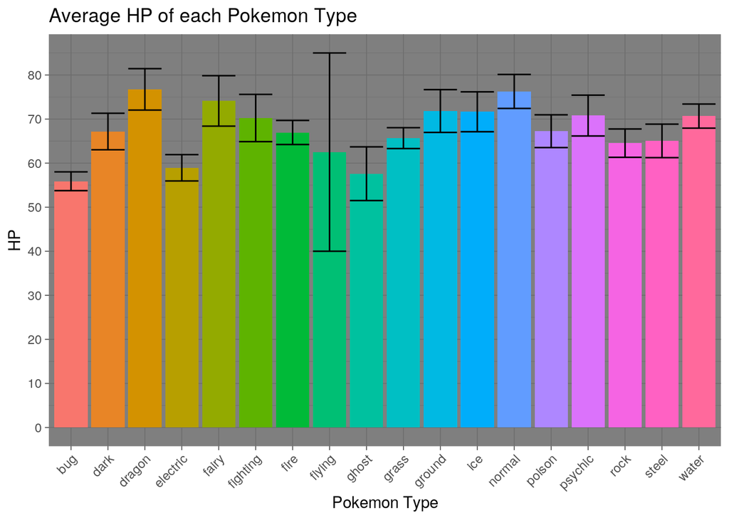

```r
ggplot(totalpokemon, aes(x = type1, y = HP), fill = type1) +
    theme_dark() + geom_bar(stat = "summary", fun = mean, aes(fill = type1)) +
    geom_errorbar(stat = "summary", fun.data = mean_se) + theme(axis.text.x = element_text(angle = 45,
    hjust = 1), legend.position = "none") + scale_y_continuous(breaks = seq(0,
    80, 10), labels = c("0", "10", "20", "30", "40", "50", "60",
    "70", "80")) + labs(x = "Pokemon Type", title = "Average HP of each Pokemon Type")
```

Pokemons are categorized into different Pokemon Types, and HP stands for Hit Points. HP is related to how much damage a Pokemon can sustain before fainting. In plot 1, I displayed the average HP by Pokemon type. I also included standard error bars for each type of Pokemon. There doesn’t appear to be one Pokemon Type that is dominating in HP over the other types. The averages and standard errors of HP across many types appear to be similar and indistinguishable.It does seem to appear that the bug type has the lowest average HP among the types, and the flying type experiences the most varied HP values. There doesn’t appear to be a strong relationship between Pokemon type and HP, but there could be possible correlation.

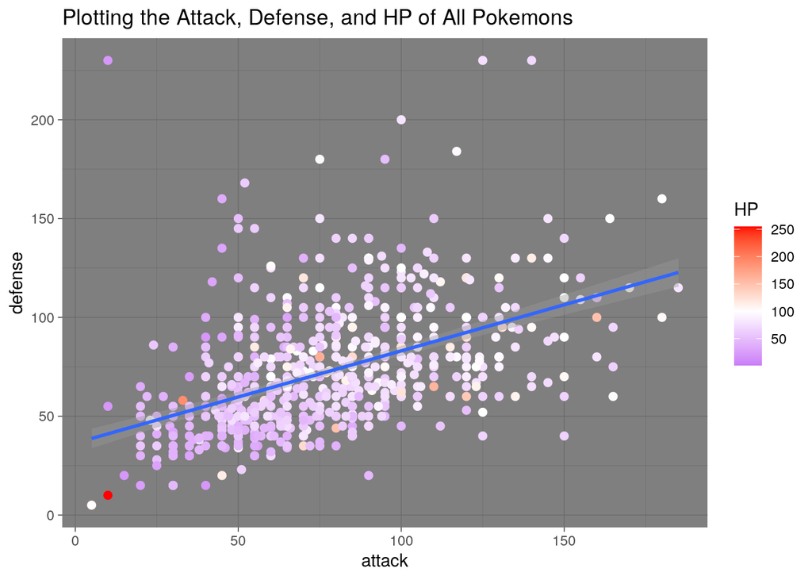

```r
ggplot(totalpokemon, aes(attack, defense)) + geom_point(size = 2,
    aes(color = HP)) + theme_dark() + scale_color_gradient2(low = "purple",
    mid = "white", high = "red", midpoint = 100) + labs(title = "Plotting the Attack, Defense, and HP of All Pokemons") +
    geom_smooth(method = "lm")
```

In addition to HP, attack and defense are also statistics related to a Pokemon’s strength. A high attack score relates to high attack power, and the same principle applies to defense. In plot 2, I plotted attack, defense, and HP values for all Pokemon to see if there was a correlation between these variables. Although there appears to be a positive relationship between defense and attack values as shown by the line of best fit, there doesn’t appear to be a correlation to HP scores. The color of the points on the graph indicate the HP value for that Pokemon, and there doesn’t seem to be a trend of HP values across the different defense and attack scores. Although there does appear a more concentrated area of low HP at low attack and defense, there are also high HP values scattered among this area as well, which adds doubt.

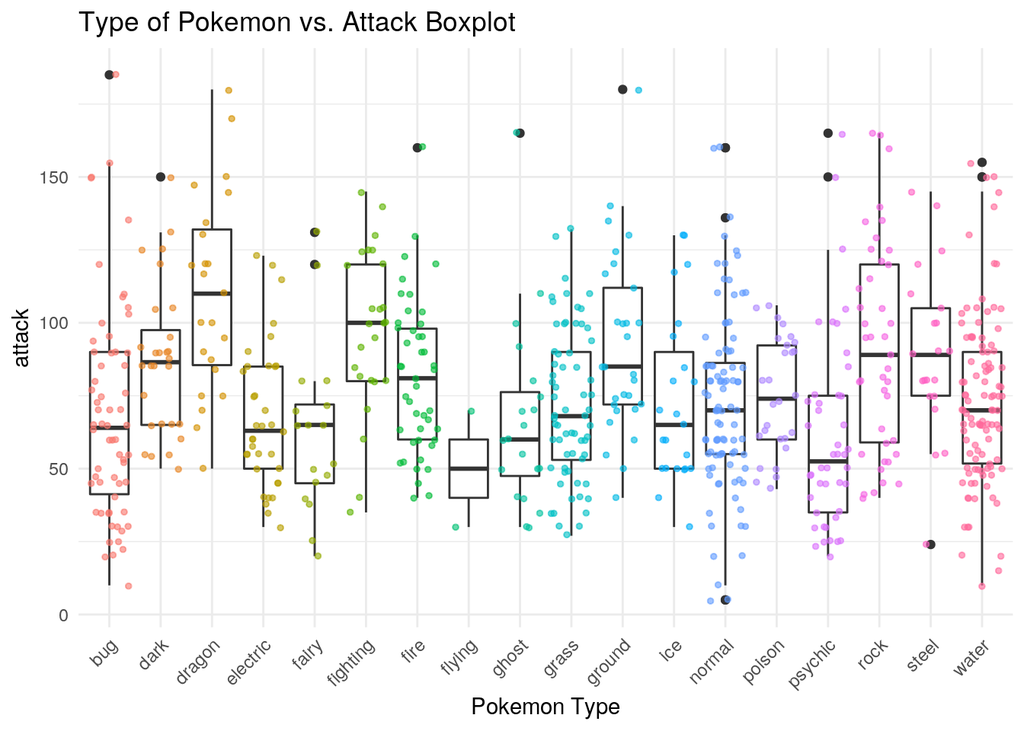

```r
ggplot(totalpokemon, aes(x = type1, y = attack)) + geom_boxplot() +
    geom_jitter(size = 1, alpha = 0.6, aes(color = type1)) +
    theme_minimal() + labs(x = "Pokemon Type", title = "Type of Pokemon vs. Attack Boxplot") +
    theme(axis.text.x = element_text(angle = 45, hjust = 1),
        legend.position = "none")
```

#### Concluding Remarks

The dataset relating to Pokemon made this project a lot more fun and engaging. I was interested and excited by the data, and it was cool to see the different plots.